# Part II - (Loan Data from Prosper - Data Analysis)

## by (Nora M)

## Investigation Overview

> In this investigation, my goal is to identify the elements that can be utilized to forecast credit default. in addition to highlighting what variables may affect the Prosper's rating

## Dataset Overview

> This data set contains more than 100K loans with 80+ variables on each loan. Additionally the data set includes loan amount, interest rate, loan status, borrower income, etc.

## (Loan status)

The majority of the loans in the data set are current loans. For Completed loans, defaulted loans are a minority, but charged-off loans nevertheless constitute a significant portion. Past-due loans are classified into numerous categories based on the length of the payment delay.

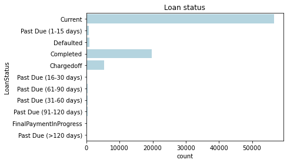

## (Stated monthly income)

The distribution of the monthly income has noticeable right skew & mode is about 5000.

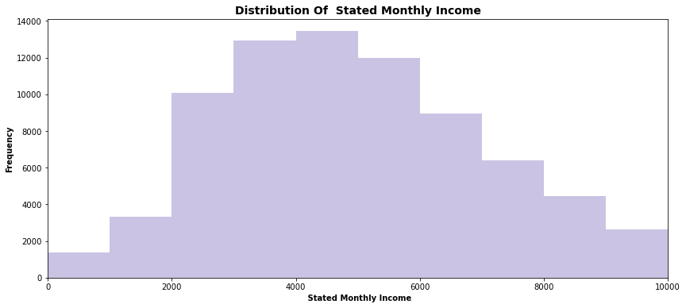

## (Employment status)

Usually, borrowers are employed

## (State & Prosper Rating:)

Most frequent rating(defaulted loans): D. Most frequent rating(completed loans): D.

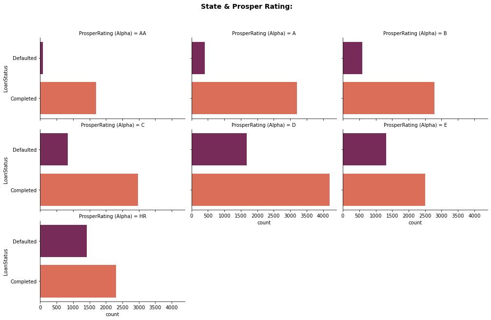

## (Listing types/categories)

The debt Consolidation was the most frequent.

## (Status & Amount)

Defaulted credits are smaller than completed credits.

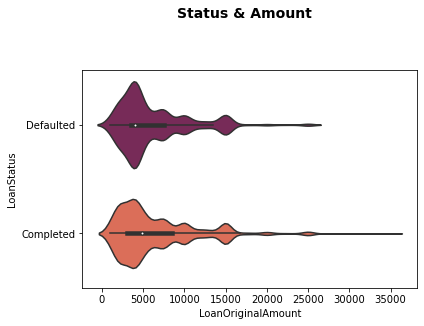

## (Rating & Employment Status)

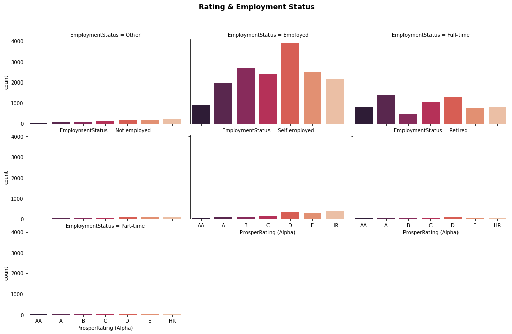

## (Loan Rating, Amount and Status)

Defaulted credits > completed. Individuals that has low Prosper rating are the source of defaulted credits.

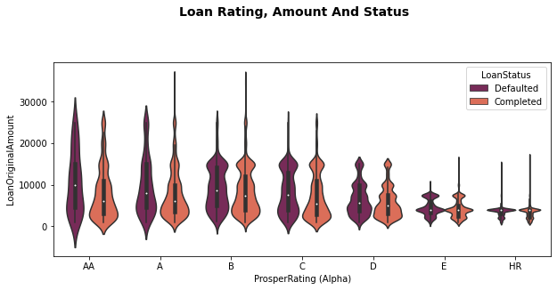

## (Credit Category, Rating, Outcome, and Their Relationship:)

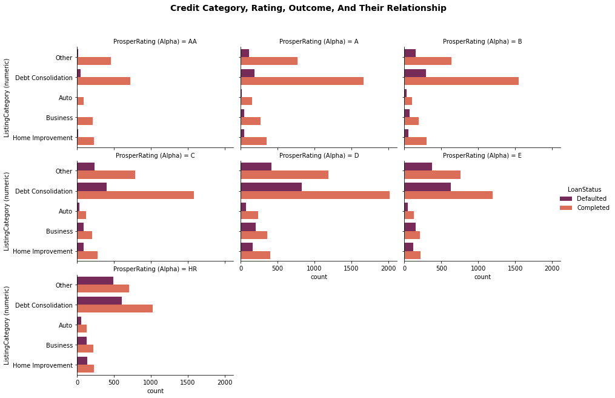